# Evaluation-of-filter-results_25x25

Kento Okuyama

2023-11-08

## (very) Brief introduction

In our implementation, our objective function **sumLik** is maximized based on the gradient vector and Adam. For evaluation purpose, we also have the score function **delta**. This is simply calculated as the summed squared error of the one-step-ahead (of the last observed time points) prediction of our intra-individual latent variables. Further, we also have **sensitivity** and **specificity** based on the one-step-ahead regime prediction results.

### N=25, T=25

First, we check the distribution of the resulting **sumLik**

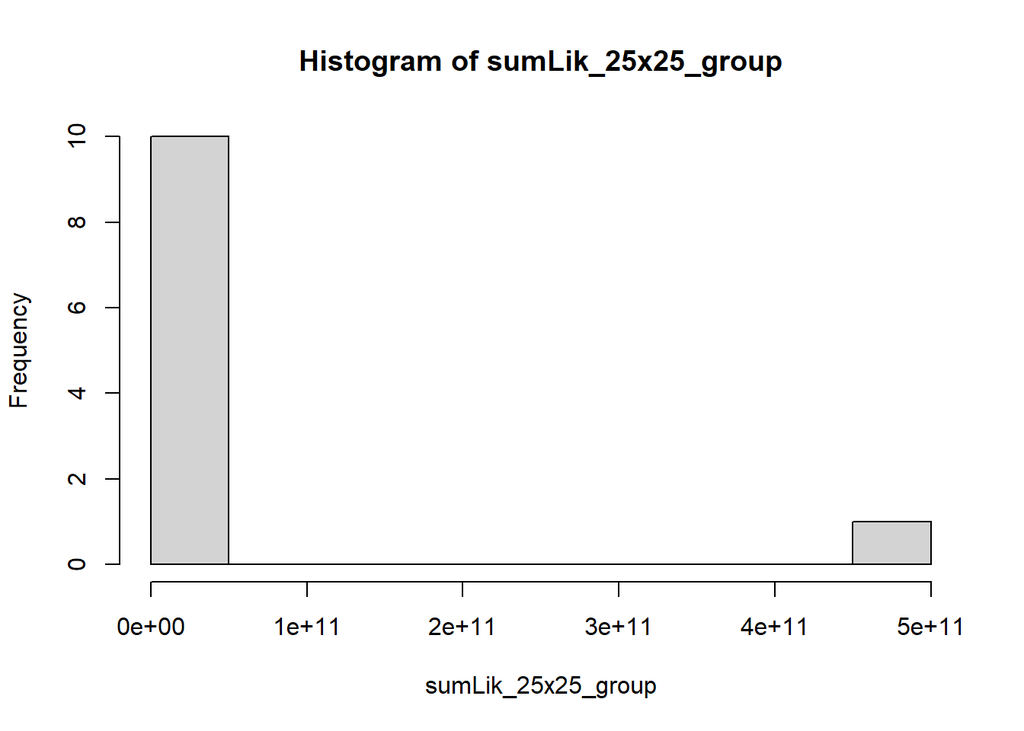

```r
hist(sumLik_25x25_group, breaks=15)
```

```r
summary(sumLik_25x25_group)
```

```
##      Min.   1st Qu.    Median      Mean   3rd Qu.      Max.
## 0.000e+00 0.000e+00 0.000e+00 4.798e+10 8.070e+02 4.895e+11
```

and in log scale

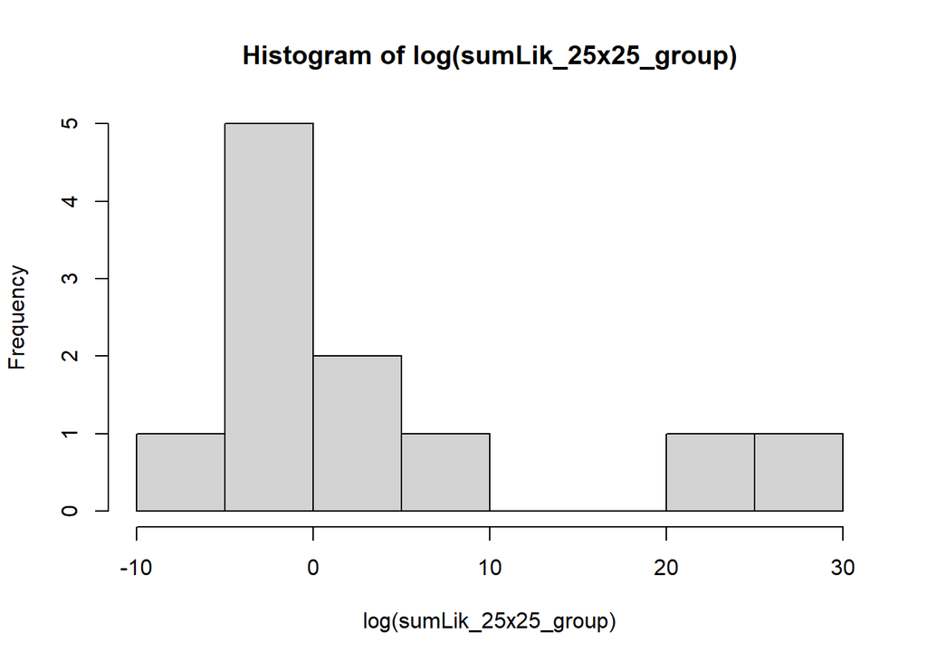

```r
hist(log(sumLik_25x25_group), breaks=10)
```

```r
summary(log(sumLik_25x25_group))
```

```
##    Min. 1st Qu.  Median    Mean 3rd Qu.    Max.
##  -5.268  -3.352  -2.313   3.769   5.203  26.917
```

It seems like there are a few instances which has much higher **sumLik** than others.

Second, we check the distribution of the resulting **delta**

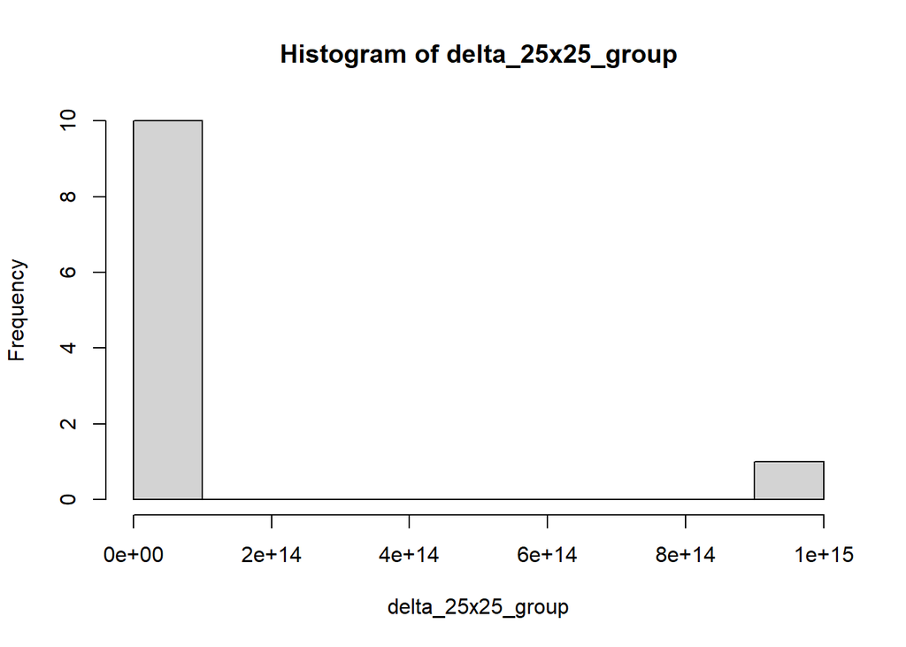

```r
hist(delta_25x25_group, breaks=10)
```

```r
summary(delta_25x25_group)
```

```
##      Min.   1st Qu.    Median      Mean   3rd Qu.      Max.
## 0.000e+00 0.000e+00 0.000e+00 9.392e+13 8.060e+02 9.785e+14
```

and in log scale

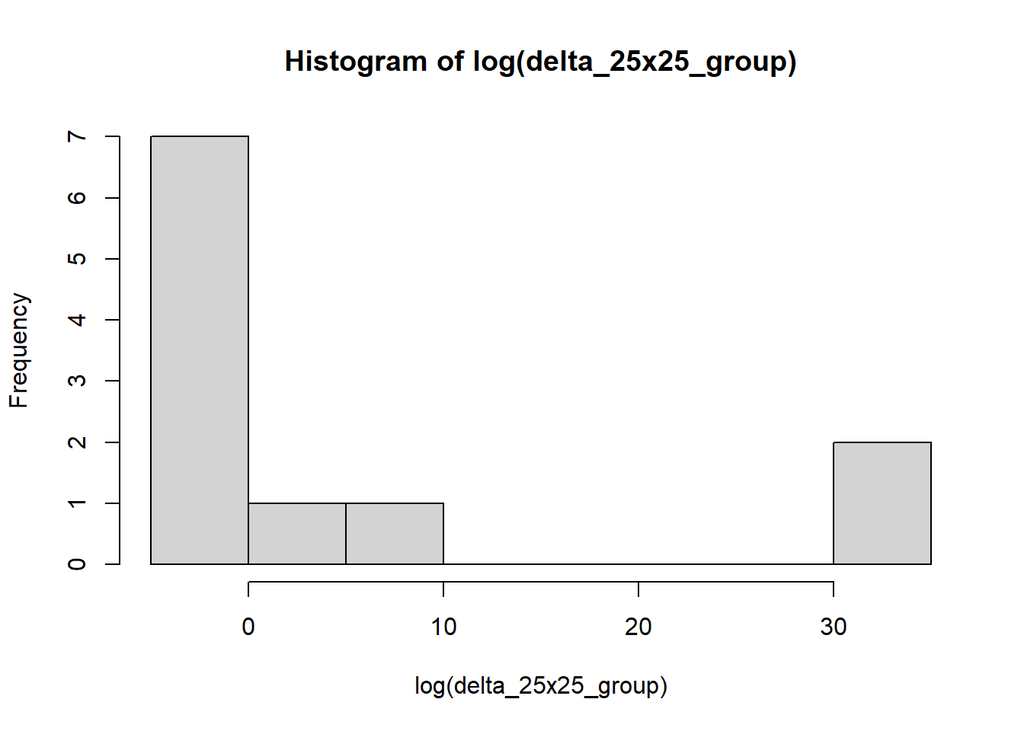

```r
hist(log(delta_25x25_group), breaks=10)
```

```r
summary(log(delta_25x25_group))
```

```
##    Min. 1st Qu.  Median    Mean 3rd Qu.    Max.
##  -1.599  -1.492  -1.117   6.044   4.901  34.517
```

Please note that we prefer a smaller value as it is calculated based on the prediction error.

Next, we turn our attention to how the **sumLik** and **delta** correlate. Intuitively, we expect the negative correlation so that higher **sumLik** (maximized likelihood) relates to smaller **delta** (smaller prediction error).

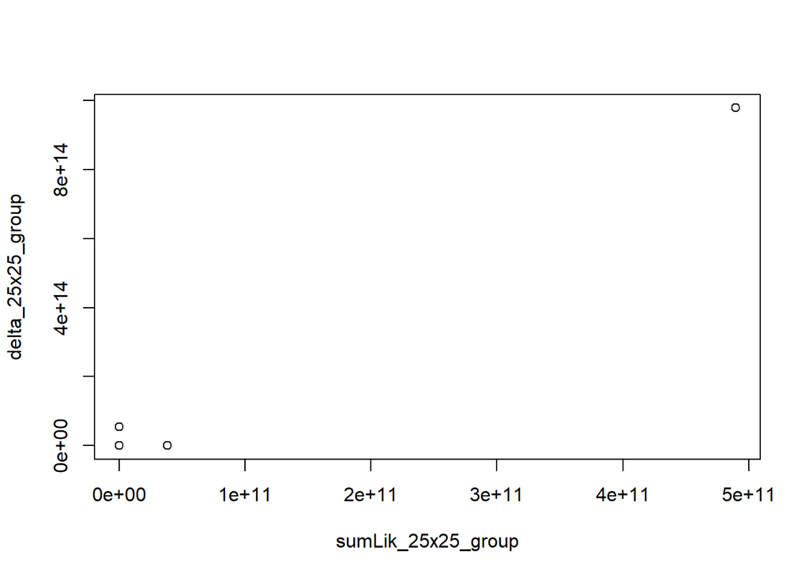

```r
plot(sumLik_25x25_group, delta_25x25_group)
```

```r
cor(sumLik_25x25_group, delta_25x25_group)
```

```
## [1] 0.994899
```

and in log scale

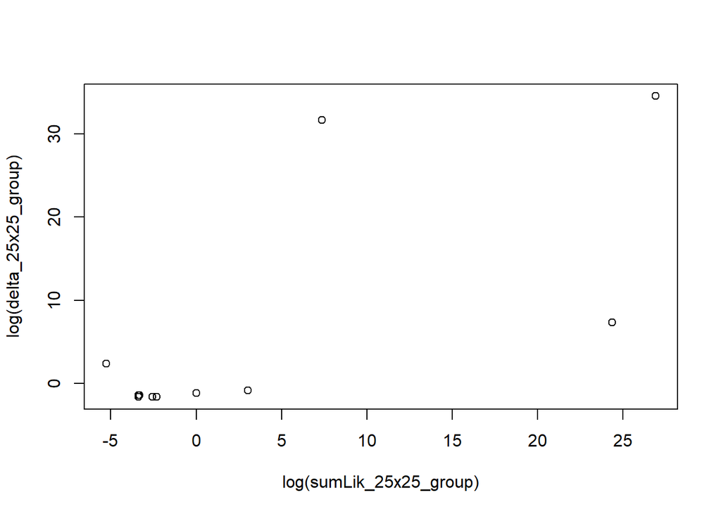

```r
plot(log(sumLik_25x25_group), log(delta_25x25_group))
```

```r
cor(log(sumLik_25x25_group), log(delta_25x25_group))
```

```
## [1] 0.7061194
```

Unfortunately, we see a positive correlation between **sumLik** and **delta**.

Then, we check the distribution of **sensitivity** and **specificity**.

First for **sensitivity**

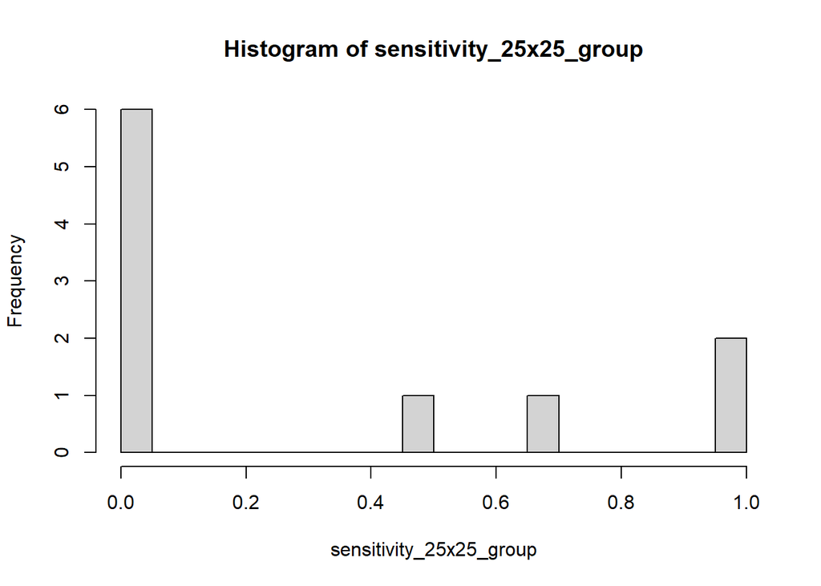

```r
hist(sensitivity_25x25_group, breaks=15)
```

```r
summary(sensitivity_25x25_group)
```

```
##    Min. 1st Qu.  Median    Mean 3rd Qu.    Max.    NA's
##  0.0000  0.0000  0.0000  0.3167  0.6250  1.0000       1
```

And for **specificity**

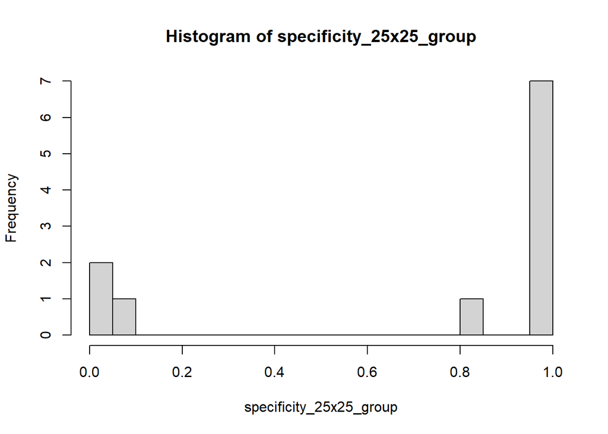

```r
hist(specificity_25x25_group, breaks=15)
```

```r
summary(specificity_25x25_group)
```

```
##    Min. 1st Qu.  Median    Mean 3rd Qu.    Max.
##  0.0000  0.4687  1.0000  0.7172  1.0000  1.0000
```

We can also check the correlation between **sensitivity** and **specificity**.

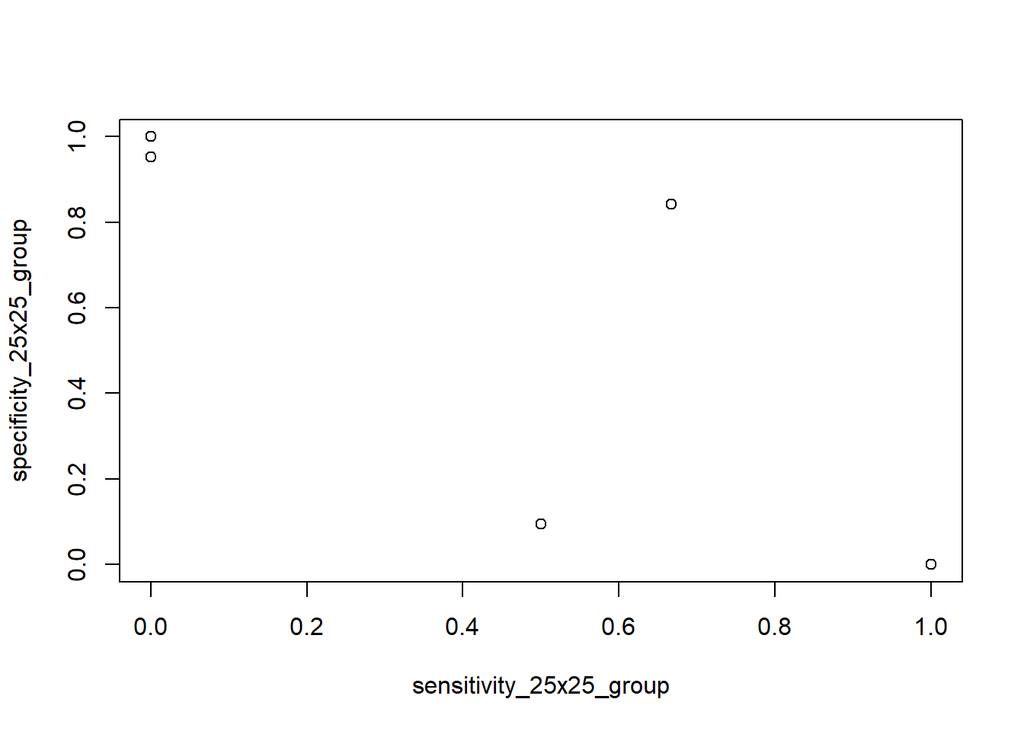

```r
plot(sensitivity_25x25_group, specificity_25x25_group)
```

```r
cor(sensitivity_25x25_group, specificity_25x25_group)
```

```
## [1] NA
```

Finally we examine our parameter estimation.

The distribution of parameter estimation are shown below. True parameter values are in parenthesis.

```r
summary(theta_25x25_group)
```

```
##    B11_1 (.2)        B11_2 (.3)         B12_1 (-.1)        B12_2 (-.2)
##  Min.   :0.04598   Min.   :0.0001961   Min.   :-0.32662   Min.   :-0.24287
##  1st Qu.:0.09054   1st Qu.:0.0911730   1st Qu.:-0.20794   1st Qu.:-0.19166
##  Median :0.15332   Median :0.1476940   Median :-0.10695   Median :-0.12721
##  Mean   :0.14126   Mean   :0.1456091   Mean   :-0.12587   Mean   :-0.12370
##  3rd Qu.:0.18749   3rd Qu.:0.1833224   3rd Qu.:-0.03609   3rd Qu.:-0.08031
##  Max.   :0.24686   Max.   :0.3064244   Max.   : 0.11377   Max.   : 0.02562
##   B21d_1 (.8)      B21d_2 (.8)      B22d_1 (.4)        B22d_2 (.4)
##  Min.   :0.6600   Min.   :0.7247   Min.   :-0.01404   Min.   :-0.01425
##  1st Qu.:0.7917   1st Qu.:0.8724   1st Qu.: 0.05899   1st Qu.: 0.07348
##  Median :0.8332   Median :0.9060   Median : 0.27215   Median : 0.14008
##  Mean   :0.8262   Mean   :0.9090   Mean   : 0.20493   Mean   : 0.15259
##  3rd Qu.:0.8586   3rd Qu.:0.9701   3rd Qu.: 0.29819   3rd Qu.: 0.21423
##  Max.   :0.9667   Max.   :1.0841   Max.   : 0.43783   Max.   : 0.42025
##    B31_1 (.1)          B31_2 (.1)         B32_1 (-.1)         B31_2 (-.1)
##  Min.   :-0.455770   Min.   :-0.421259   Min.   :-0.169639   Min.   :-0.19086
##  1st Qu.:-0.039192   1st Qu.:-0.085751   1st Qu.:-0.139317   1st Qu.:-0.15226
##  Median : 0.037347   Median :-0.006475   Median :-0.108546   Median :-0.09901
##  Mean   : 0.009683   Mean   : 0.001331   Mean   :-0.066541   Mean   :-0.10112
##  3rd Qu.: 0.147424   3rd Qu.: 0.105658   3rd Qu.:-0.007457   3rd Qu.:-0.04799
##  Max.   : 0.181093   Max.   : 0.515602   Max.   : 0.112690   Max.   :-0.01851
##    Lmdd_1 (1)   Lmdd_2 (0)  Lmdd_3 (.4)       Lmdd_4 (0)  Lmdd_5 (.8)
##  Min.   :1    Min.   :0    Min.   :0.3311   Min.   :0    Min.   :0.5519
##  1st Qu.:1    1st Qu.:0    1st Qu.:0.4224   1st Qu.:0    1st Qu.:0.7952
##  Median :1    Median :0    Median :0.8346   Median :0    Median :0.9662
##  Mean   :1    Mean   :0    Mean   :0.7128   Mean   :0    Mean   :0.9226
##  3rd Qu.:1    3rd Qu.:0    3rd Qu.:0.9323   3rd Qu.:0    3rd Qu.:1.0186
##  Max.   :1    Max.   :0    Max.   :1.0964   Max.   :0    Max.   :1.3587
##    Lmdd_6 (0)   Lmdd_7 (0)   Lmdd_8 (1)   Lmdd_9 (0)  Lmdd_10 (.5)
##  Min.   :0    Min.   :0    Min.   :1    Min.   :0    Min.   :0.3006
##  1st Qu.:0    1st Qu.:0    1st Qu.:1    1st Qu.:0    1st Qu.:0.5055
##  Median :0    Median :0    Median :1    Median :0    Median :0.7044
##  Mean   :0    Mean   :0    Mean   :1    Mean   :0    Mean   :0.7654
##  3rd Qu.:0    3rd Qu.:0    3rd Qu.:1    3rd Qu.:0    3rd Qu.:0.9952
##  Max.   :0    Max.   :0    Max.   :1    Max.   :0    Max.   :1.3252
##   Lmdd_11 (0) Lmdd_12 (1.2)     Qd_1 (.2)          Qd_2 (.2)
##  Min.   :0    Min.   :0.785   Min.   :0.001000   Min.   :0.001928
##  1st Qu.:0    1st Qu.:1.010   1st Qu.:0.001261   1st Qu.:0.004204
##  Median :0    Median :1.200   Median :0.003391   Median :0.014012
##  Mean   :0    Mean   :1.137   Mean   :0.080300   Mean   :0.082226
```

[output cut: 8 more lines]

```
##  Max.   :0.37731   Max.   :0.37540   Max.   :0.37658   Max.   :0.37686
##    Rd_5 (.3)         Rd_6 (.3)        gamma1 (3.5)    gamma2_1 (1)
##  Min.   :0.03637   Min.   :0.05725   Min.   :4.119   Min.   :0.1367
##  1st Qu.:0.04818   1st Qu.:0.08858   1st Qu.:4.123   1st Qu.:0.4973
##  Median :0.09891   Median :0.25469   Median :4.374   Median :0.9609
##  Mean   :0.20335   Mean   :0.23089   Mean   :4.284   Mean   :0.9676
##  3rd Qu.:0.37444   3rd Qu.:0.37380   3rd Qu.:4.421   3rd Qu.:1.4197
##  Max.   :0.37628   Max.   :0.37607   Max.   :4.467   Max.   :1.8823
##   gamma2_2 (1)
##  Min.   :0.3806
##  1st Qu.:0.6923
##  Median :0.9778
##  Mean   :0.9928
##  3rd Qu.:1.2809
##  Max.   :1.5814
```